# Lab 6

Author

Aiden Roach

Published

April 14, 2025

## The Data

In this lab we’re going look at the median weekly cost of childcare in California. A detailed description of the data can be found [here](https://github.com/rfordatascience/tidytuesday/blob/master/data/2023/2023-05-09/readme.md).

The data come to us from [TidyTuesday](https://github.com/rfordatascience/tidytuesday).

**0. Load the appropriate libraries and the data.**

```r
library(tidyverse)
```

```r
childcare_costs <- read_csv('https://raw.githubusercontent.com/rfordatascience/tidytuesday/master/data/2023/2023-05-09/childcare_costs.csv')
counties <- read_csv('https://raw.githubusercontent.com/rfordatascience/tidytuesday/master/data/2023/2023-05-09/counties.csv')
```

**1. Briefly describe the dataset (~ 4 sentences). What information does it contain?**

> The childcare dataset looks at the cost of childcare by county in the United States from 2008 to 2018. The data contains information on unemployment rates by age range and gender, labor force rates by age range and gender, poverty rates, median household income by gender and overall, racial demographics, the number of households, number of workers per household, type of workforce, and cost of childcare by age range. The counties dataset provides a list of the counties that data was supplied for. I thought it was interesting that New Mexico, Indiana, and the majority of Missouri have no data available.

## California Childcare Costs

Let’s start by focusing only on California.

**2. Create a `ca_childcare` dataset of childcare costs in California, containing (1) county information and (2) just the year and childcare cost variable information from the `childcare_costs` dataset.**

```r
ca_childcare <- childcare_costs |>
  left_join(counties) |>
  filter(state_abbreviation == "CA") |>
  select(study_year, mhi_2018, mcsa, mfccsa, mc_infant, mc_toddler, mc_preschool, county_name)
```

**3. Using a function from the `forcats` package, complete the code below to create a new variable where each county is categorized into one of the [10 Census regions](https://census.ca.gov/regions/) in California. Use the Region description (from the plot), not the Region number. An example region has been started for you.**

*Hint: This is probably a good place to use ChatGPT to reduce on tedious work. But you do need to know how to prompt ChatGPT to make it useful!*

```r
ca_childcare <- ca_childcare |>
  mutate(county_name = str_remove(county_name, " County")) |>
  mutate(region = fct_collapse(county_name,
    'Superior California' = c("Butte", "Colusa", "El Dorado", "Glenn", "Lassen", "Modoc", "Nevada", "Placer", "Plumas", "Sacramento", "Shasta", "Sierra", "Siskiyou", "Sutter", "Tehama", "Yolo", "Yuba"),
    'North Coast' = c("Del Norte", "Humboldt", "Lake", "Mendocino", "Napa", "Sonoma", "Trinity"),
    'San Francisco Bay Area' = c("Alameda", "Contra Costa", "Marin", "San Francisco", "San Mateo", "Santa Clara", "Solano"),
    'Northern San Joaquin Valley' = c("Alpine", "Amador", "Calaveras", "Madera", "Mariposa", "Merced", "Mono", "San Joaquin", "Stanislaus", "Tuolumne"),
    'Central Coast' = c("Monterey", "San Benito", "San Luis Obispo", "Santa Barbara", "Santa Cruz", "Ventura"),
    'Southern San Joaquin Valley' = c("Fresno", "Inyo", "Kern", "Kings", "Tulare"),
    'Inland Empire' = c("Riverside", "San Bernardino"),
    'Los Angeles' = c("Los Angeles"),
    'Orange' = c("Orange"),
    'San Diego - Imperial' = c("Imperial", "San Diego")))
```

**4. Let’s consider the median household income of each region, and how that income has changed over time. Create a table with ten rows, one for each region, and two columns, one for 2008 and one for 2018. The cells should contain the `median` of the median household income (expressed in 2018 dollars) of the `region` and the `study_year`. Arrange the rows by 2018 values.**

```r
# Hint: You will want to calculate the median of median income before you make columns for 2008/2018 by transforming the data
ca_childcare |>
  select(region, study_year, mhi_2018) |>
  filter(study_year == 2008 | study_year == 2018) |>
  group_by(region, study_year) |>
  summarize(region_income = median(mhi_2018)) |>
  ungroup() |>
  select(region, study_year, region_income) |>
  arrange(desc(region_income)) |>
  pivot_wider(names_from = study_year, values_from = region_income)
```

```
# A tibble: 10 × 3
   region                       `2018` `2008`
   <fct>                         <dbl>  <dbl>
 1 San Francisco Bay Area      104552  90412.
 2 Orange                       85398  86452.
 3 Central Coast                74849  72979
 4 Inland Empire                62056  65977.
 5 Los Angeles                  64251  63471.
 6 San Diego - Imperial         60344. 58201.
 7 Northern San Joaquin Valley  57769  59108.
 8 Superior California          53270  57831.
 9 Southern San Joaquin Valley  52479  52676.
10 North Coast                  45528  47862.
```

**5. Which California `region` had the lowest `median` full-time median weekly price for center-based childcare for infants in 2018? Does this `region` correspond to the `region` with the lowest `median` income in 2018 that you found in Q4?**

*Hint: The code should give me the EXACT answer. This means having the code output the exact row(s) and variable(s) necessary for providing the solution. Consider the `slice()` functions.*

```r
ca_childcare |>
  select(region, study_year, mc_infant) |>
  filter(study_year == 2018) |>
  group_by(region, study_year) |>
  summarize(region_infant = median(mc_infant)) |>
  ungroup() |>
  select(region, study_year, region_infant) |>
  arrange(desc(region_infant)) |>
  pivot_wider(names_from = study_year, values_from = region_infant) |>
  slice_tail()
```

```
# A tibble: 1 × 2
  region              `2018`
  <fct>                <dbl>
1 Superior California   215.
```

> This region does not correspond to the region with the lowest median income in 2018 from Q4. The region with the lowest median income in 2018 was the North Coast region while the region that had the lowest median full-time median weekly price for center-based childcare for infants in 2018 was Superior California.

**6. Recreate the plot (look at online instructions) that shows, for all ten regions, the change over time of the full-time median price for center-based childcare for infants, toddlers, and preschoolers. Recreate the plot. You do not have to replicate the exact colors or theme, but your plot should have the same content, including the order of the facets and legend, reader-friendly labels, axes breaks, and a smooth function.**

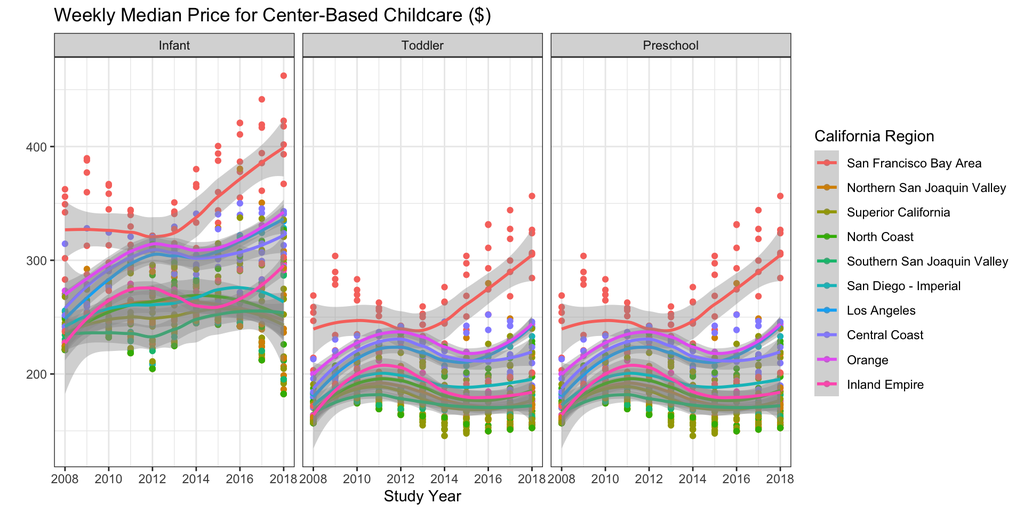

```r
ca_childcare |>
  select(region, study_year, mc_infant, mc_toddler, mc_preschool) |>
  pivot_longer(cols = 3:5, names_to = "age_range", values_to = "median_cost") |>
  mutate(age_range = recode(age_range, "mc_infant" = "Infant", "mc_toddler" = "Toddler", "mc_preschool" = "Preschool")) |>
  ggplot(mapping = aes(x = study_year, y = median_cost, color = region)) +
  geom_point() +
  geom_smooth() +
  facet_grid(~fct_inorder(age_range)) +
  scale_x_continuous(breaks = seq(2008, 2018, 2)) +
  labs(title = "Weekly Median Price for Center-Based Childcare ($)", x = "Study Year", color = "California Region", y = "") +
  theme_bw()
```